# Importação, manipulação e visualização de dados

Linguagens de Programação para Ciência de Dados

Prof. Dr. Walmes M. Zeviani  
walmes@ufpr.br

2018-03-24

# Objetivos e justificativa

### Justificativa

O préprocessamento de dados a maior etapa dentro do workflow de Data Science.

### Objetivos

- Introduzir as linguagens de programação R e Python.
  - Fundamentos da linguagem de programação.
  - Algorítmos e estruturas de dados.
  - Principais recursos para leitura, manipulação e visualização de dados.

# Ementa

1. Introdução e configuração do ambiente de programação.
   1. Operações aritméticas e lógicas.
   2. Estruturas de controle e repetições.
   3. Programação orientada à objetos e funções.
2. Leitura e manipulação de dados.
   1. Dados no formato texto.
   2. Dados em bancos de dados.
   3. Aquisição de dados pela internet (web scraping).
3. Análise exploratória e visualização interativa de dados.

# Onde estamos para onde vamos

- Até aqui
  - Fundamentos da linguagem.
  - Estruturas de dados.
  - Estruturas de programação.
  - Manipulação dos *containers* básicos de dados.
- A partir daqui
  - Leitura de dados em arquivo texto e de banco de dados.
  - Manipulação e tratamento de dados.
  - Estatística descritiva.
  - Visualização de dados.
  - Noções de programação avançada.

# Landscape de manipulação de dados

Considerando apenas os dados em formato tabular

- R básico
  - Recursos disponíveis no conjunto de pacotes base/recommended do R.
  - Recursos extras em outros pacotes: `foreign`, `gdata`, `xlsReadWrite`, `XLConnect`, `xlsx`.
  - Leitura e manipulação de dados de porte pequeno e médio.
  - Muitos usuários de R nunca precisaram sair dessa vizinhança para resolver seus problemas.
- [`data.table`](https://cran.r-project.org/web/packages/data.table)
  - Único pacote com foco principal em performance (e.g. ~100GB in RAM).
  - Possui sintaxe própria e internamente consistente.
  - Performance para ordenação, junções, modificações, paralelização.
- [`tidyverse`](https://cran.r-project.org/web/packages/tidyverse/)
  - É uma colecação de pacotes que trabalham em harmonia.
  - Cada pacote dentro da coleção tem um tema específico.
  - O foco é a sintaxe coesa e clara que estimula o desenvolvimento.
  - É o fio condutor do livro [R for Data Science](http://r4ds.had.co.nz/).
- Para bancos de dados
  - Representa o conjunto de pacotes do R que provém interfaces para bancos de dados.
  - Para cada arquitetura existe um conjunto recomendado de pacotes.
  - O R é o cliente e as operações podem ser executadas no banco de dados.
  - E.g. `odbc`, `RMySQL`, `RSQLite`, `RODBC`, `mongolite`, `RCassandra`, `elasticsearchr`, etc.

# Landscape de visualização de dados

- R básico
  - Funções de alto e baixo nível do pacote [`graphics`](https://www.stat.auckland.ac.nz/~paul/RGraphics/chapter1.pdf).
  - Fornece recursos para gráficos tradicionais.
  - Outros pacotes estendem as funcionalidades: e.g. [`plotrix`](https://cran.r-project.org/web/packages/plotrix).
- [`lattice`](http://lattice.r-forge.r-project.org/index.php)
  - Pacote do conjunto recommended.
  - É um sistema de visualização de alto nível com enfase em dados multivariados.
  - Recursos para a visualização tradicional.
  - Outros pacotes estendem as funcionalidades: e.g. [`latticeExtra`](http://latticeextra.r-forge.r-project.org/).
- [`ggplot2`](http://ggplot2.org/)
  - O mais popular em círculos de ciência de dados.
  - É integrante da coleção `tidyverse`.
  - É baseado na *gramar of graphics*.
  - Na sintaxe de gramática, os elementos gráficos são camadas.
- Mapas
  - A visualização de dados espaciais é um continente a parte.
  - Existem pacotes com recursos de ponta a ponta (leitura, manipulação e visualização) e outros com recursos espefícos.
- Visualização dinâmica/interativa
  - Visualização orientada para a WEB.
  - [`plotly`](https://plot.ly/r/)
  - [`highcharter`](http://jkunst.com/highcharter/).
  - [`googleVis`](https://cran.r-project.org/web/packages/googleVis/vignettes/googleVis_examples.html).
  - [`rCharts`](https://ramnathv.github.io/rCharts/).
  - [`leaflet`](https://rstudio.github.io/leaflet/).
  - [`iplots`](http://rosuda.org/software/iPlots/).
  - [`rgl`](https://cran.r-project.org/web/packages/rgl/vignettes/rgl.html).
  - [`animation`](https://yihui.name/animation/).

# O que veremos hoje?

- Leitura, manipulação e visualização de dados.
- Fio condutor: Dados do Hackathon de Data Science
  - O que são: avaliação usuários de veículos (*customer review*)
  - De onde são: web scraping do http://www.carrosnaweb.com.br/opiniao.asp.
  - Dimensão: porte médio.
  - Condição: são dados reais e selvagens!
  - Requerem: domesticação
- Objetivo:
  - Fazer a leitura dos dados.
  - Aplicar operações para compreender e organizar os dados.
  - Integrar os dados.
  - Fazer análise exploratória.

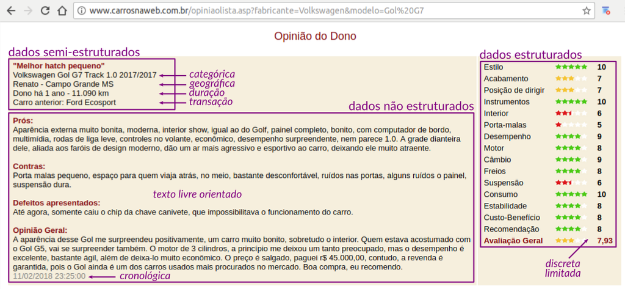

# Material

- Disponível no moodle.
- Executar e discutir em laboratório.